# Check formula of SE analytically and using simulations

Andrey Ziyatdinov

2018-01-16

# 1 Prelinimaries

```r
compute_power <- function(ncp, alpha = 0.05, df = 1, lower = FALSE)
{
  q_alpha <- qchisq(alpha, df = df, lower = lower)

  power <- pchisq(q_alpha, df = df, ncp = ncp, lower = lower)
}
```

# 2 Parameters

```r
M <- 5e2 # the number of SNPs
N <- as.integer(c(1e2, 5e2, 1e3, 2e3)) # the number of individuals
p <- 0.3 # the MAF of SNPs
f <- 0.5 # the frequency of binary exposure
betaG <- 0.1 # the effect size (simulations on the main genetic effect)

var_explained <- 0.6 # the variance explained by polygenic effect (h2)

ibetaG <- 0.1 # the marginal genetic effect size (GxE simulations)
ibetaE <- 0.1 # the marginal environmental effect size
ibetaGE <- 0.1 # the interaction effect size
```

# 3 Analytical formulas

We state that the difference between two NCPs (for GWAS analysis) for unrelated and genetically related designs is by **trace factor**:

- testing main genetic (marginal) effect: $trace(\hat{V}^{-1}K) / N$;
- testing interaction GxE effect: $trace(\hat{V}^{-1}K_D) / N$,
  - where $K_d$ is the element-wise product of $K$ and $D$ matrices ($D$ matrix encodes whether two individuals belong to the same exposure strata when the exposure is binary) (Sul 2016).

## 3.1 Errata

In the PGSG Seminars [talk](http://variani.github.io/talks/2017/01-gxe-related/01-gxe-related.html), we erroneously stated:

$\Sigma_{x_{ge}} = \sigma^2_{x_g} K \sigma^2_{x_e} I = \sigma^2_{x_g} \sigma^2_{x_e} I$

It should have been:

$\Sigma_{x_{ge}} = \sigma^2_{x_g} K \sigma^2_{x_e} D = \sigma^2_{x_g} \sigma^2_{x_e} K_D$

## 3.2 Marginal genetic effect

| Study | Model | Genotype $x_g$ | Std. Error ($\hat{\beta_g}$) | Approximation |
| --- | --- | --- | --- | --- |
| Unrelated | $y \sim (\mu + \beta_g g, \sigma_r^2 I)$ | $x_g \sim (pq, 2pq I)$ | $\frac{\sigma_r^2}{x_g^T x_g}$ | $\frac{\sigma_r^2}{2pq N} \approx \frac{1}{2pq N}$ |
| Genetically related | $y \sim (\mu + \beta_g g, \sigma_g^2 K + \sigma_r^2 I)$ | $x_g \sim (pq, 2pq K)$ | $\frac{{\sigma_r^*}^2}{x_g^T \hat{V}^{-1} x_g}$ | $\frac{{\sigma_r^*}^2}{2pq \mbox{ } trace(\hat{V}^{-1}K)} \approx \frac{1}{2pq \mbox{ } trace(\hat{V}^{-1}K)}$ |

Notes

- $x_g$ is centered in the formula for Std. Error ($\hat{\beta_g}$)

### 3.2.1 Case of sib-pairs

We previously derived [here](https://hemostat.github.io/Public/gxefam/vignettes/formulas.html):

$trace(V^{-1}K) = trace([\sigma_g^2 I + \sigma_r^2 K^{-1}]^{-1}) = \frac{N}{s} (\frac{1}{\sigma_g^2 + 2 \sigma_r^2 / (1 + s)} + \frac{s-1}{\sigma_g^2 + 2 \sigma_r^2})$

- $s$ is the number of siblings per family
- $N$ is the total number of individuals
- $N/s$ is the number of families

## 3.3 Interaction GxE effect

[output not shown]

Notes

- $x_g$ and $x_e$ are assumed to be independent.
- Given the independence between $x_g$ and $x_e$, the effects sizes $\beta_g$, $\beta_e$ and $\beta_{ge}$ are also independent if:
  - $x_g$ and $x_e$ are centered
  - $x_{ge}$ is derived by element-wise multiplication of **centered** $x_g$ and $x_e$

# 4 Marginal genetic effect

## 4.1 Unrelated

| Study | Model | Genotype $x_g$ | Variance of $\hat{\beta_g}$ | Approximation |
| --- | --- | --- | --- | --- |
| Unrelated | $y \sim (\mu + \beta_g g, \sigma_r^2 I)$ | $x_g \sim (pq, 2pq I)$ | $\frac{\sigma_r^2}{x_g^T x_g}$ | $\frac{\sigma_r^2}{2pq N}$ |

```r
out <- lapply(N, function(n) {
  par <- gxefam_par(num_fam = n / 5, sim_gen = "rbinom", sim_phen = "no_rand",
    freq_g  = p)

  dat <- gxefam_sim_dat(par, n = M, beta = c(betaG, 0, 0))

  assoc <- with(dat, matreg(Y = Y, X = G))

  mutate(assoc$tab,
    N = as.integer(n), sim = "unrel")
})
tab1 <- bind_rows(out)
```

```r
tab1_expected <- data_frame(N = N, beta = betaG, sigma2 = 1) %>%
  mutate(
    se = 1 / sqrt(2 * p * (1 - p) * N),
    ncp = (beta / se)^2,
    power = compute_power(ncp))

tab1_power <- group_by(tab1, N) %>% summarize(power = mean(pval < 0.05))
```

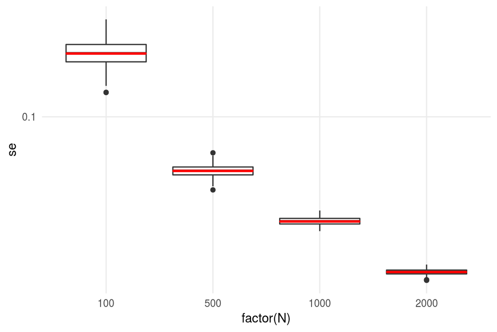

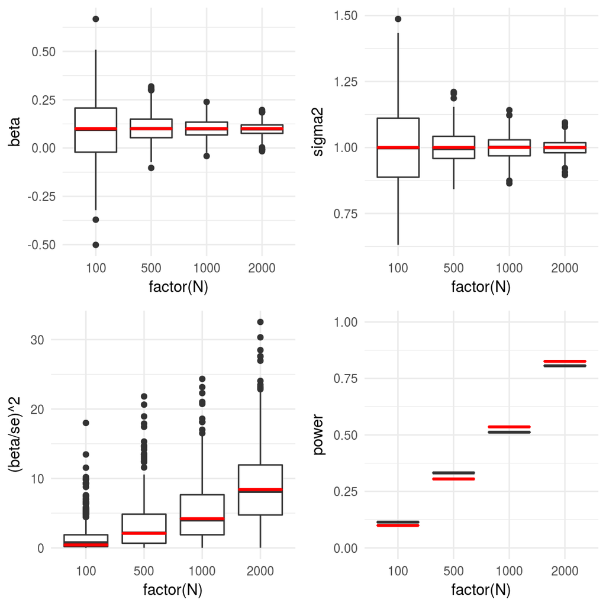

## 4.2 Genetically related

```r
out <- lapply(N, function(n) {
  par <- gxefam_par(num_fam = n / 5, sim_gen = "rbinom_fam",
    sim_phen = "gen", var_explained = var_explained,
    freq_g = p)

  dat <- gxefam_sim_dat(par, n = M, beta = c(betaG, 0, 0))

  assoc <- with(dat, matreg(Y = Y, X = G, varcov = varcov))

  list(
    par = par,
    tab = mutate(assoc$tab,
      N = as.integer(n), sim = "rel_gen"))
})
tab2 <- lapply(out, function(x) x$tab) %>% bind_rows
```

```r
tab2_expected <- data_frame(N = N, beta = betaG, sigma2 = 1) %>%
  mutate(
    trace_factor = sapply(out, function(x) gxefam_trace_factor(x$par, mult = "K")),
    se = 1 / (sqrt(2 * p * (1 - p) * N) * trace_factor),
    ncp = (beta / se)^2,
    power = compute_power(ncp))

tab2_power <- group_by(tab2, N) %>% summarize(power = mean(pval < 0.05))
```

```r
tab2_expected
```

```
# A tibble: 4 x 7
      N  beta sigma2 trace_factor     se   ncp  power
  <int> <dbl>  <dbl>        <dbl>  <dbl> <dbl>  <dbl>
1   100 0.100   1.00        0.825 0.187  0.286 0.0834
2   500 0.100   1.00        0.825 0.0836 1.43  0.223
3  1000 0.100   1.00        0.825 0.0591 2.86  0.394
4  2000 0.100   1.00        0.825 0.0418 5.72  0.667
```

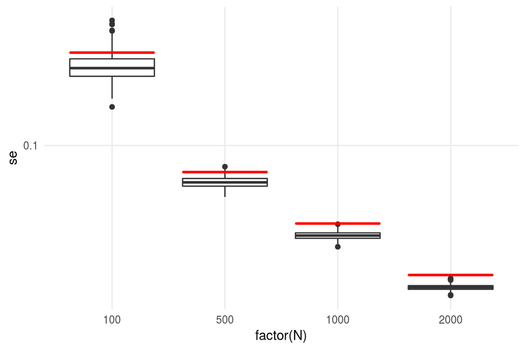

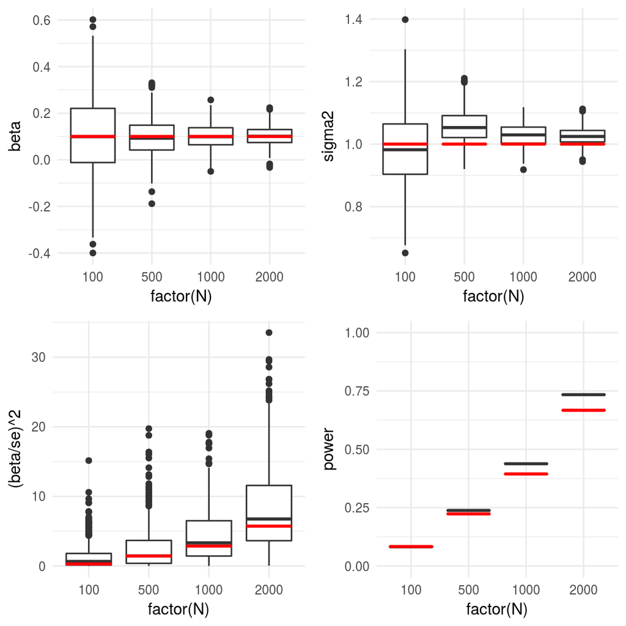

## 4.3 Comparison between unrelated and related (simulations)

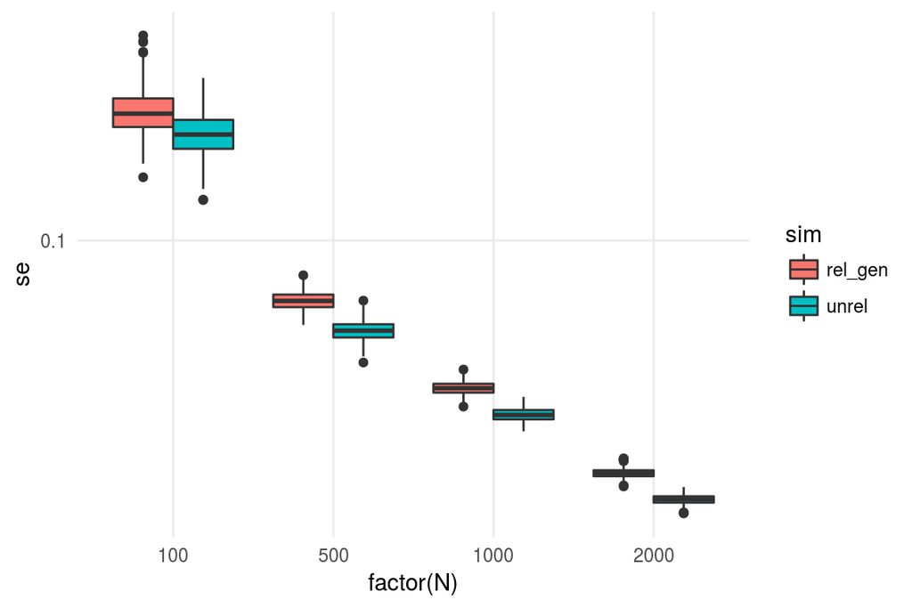

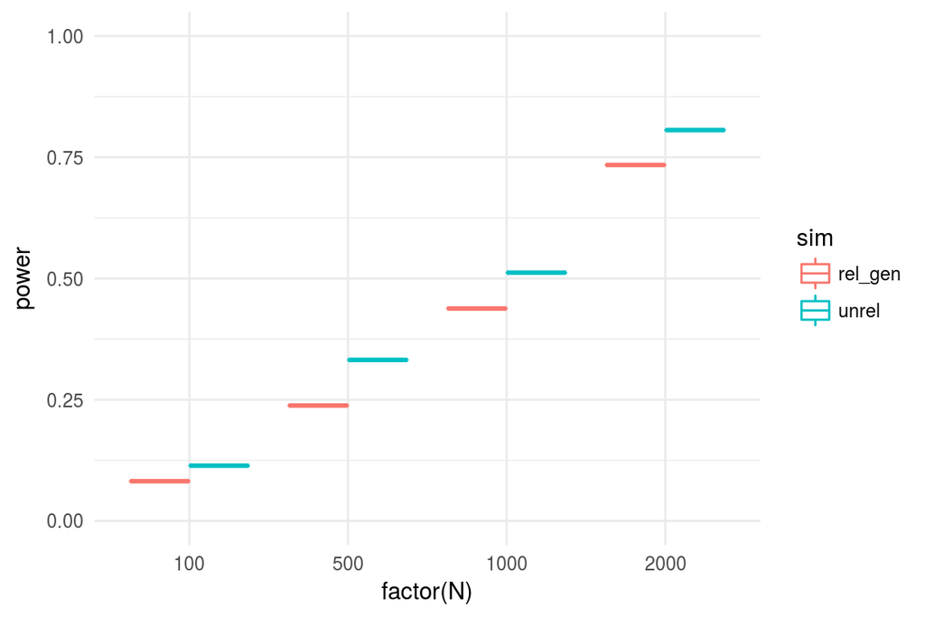

# 5 Interaction GxE effect

## 5.1 Unrelated

```r
out <- lapply(N, function(n) {
  par <- gxefam_par(num_fam = n / 5, sim_gen = "rbinom", sim_phen = "no_rand",
    freq_g  = p, freq_e = f)

  dat <- gxefam_sim_dat(par, n = M, center = TRUE, beta = c(ibetaG, ibetaE, ibetaGE))

  assoc <- with(dat, matreg(Y = Y, X = GE, Xlist = list(G, E)))

  mutate(assoc$tab,
    N = as.integer(n), sim = "unrel")
})
tab3 <- bind_rows(out)
```

```r
tab3_expected <- data_frame(N = N, beta = ibetaGE, sigma2 = 1) %>%
  mutate(
    se = 1 / sqrt(2 * p * (1 - p) * f * (1 - f) * N),
    ncp = (beta / se)^2,
    power = compute_power(ncp))

tab3_power <- group_by(tab3, N) %>% summarize(power = mean(pval < 0.05))
```

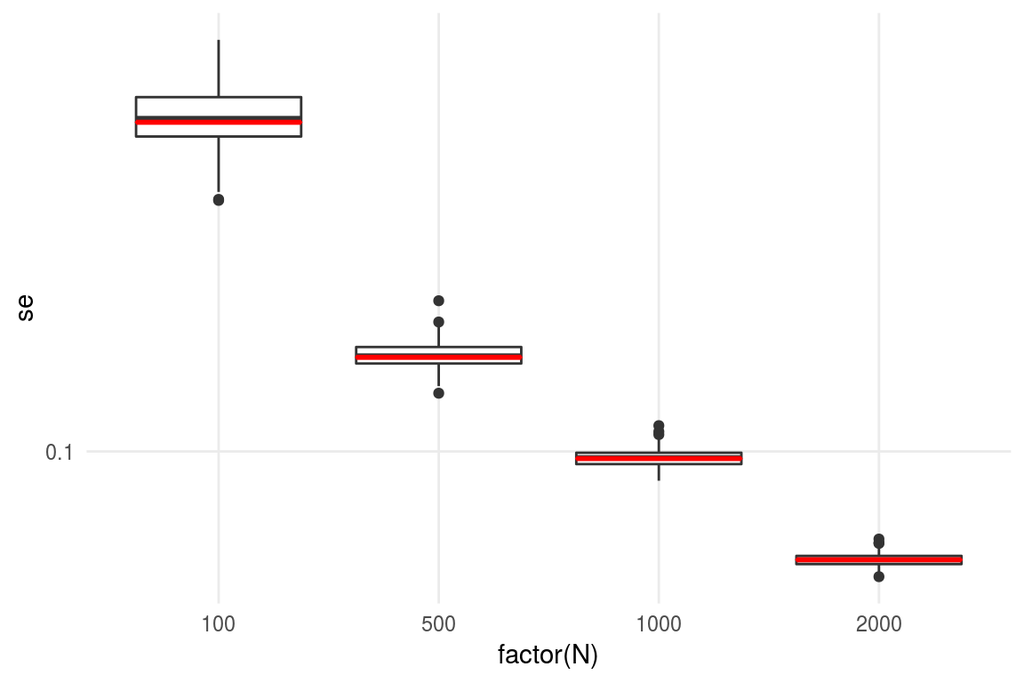

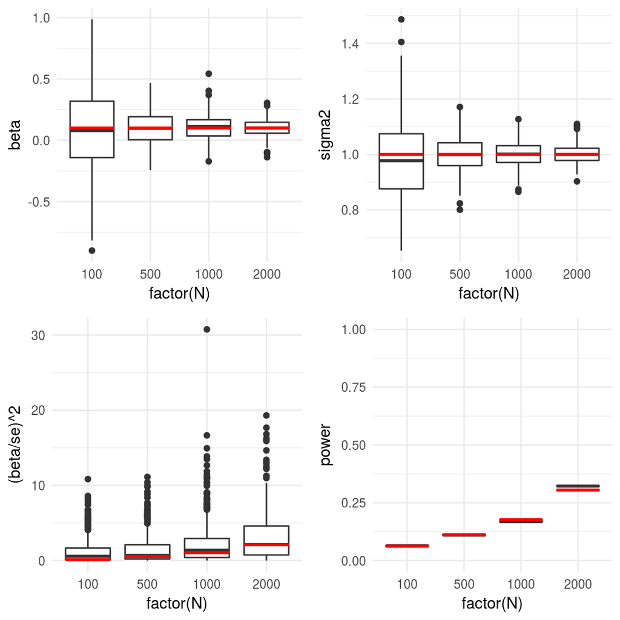

## 5.2 Genetically related

```r
out <- lapply(N, function(n) {
  par <- gxefam_par(num_fam = n / 5, sim_gen = "rbinom_fam",
    sim_phen = "gen", var_explained = var_explained,
    freq_g  = p, freq_e = f)

  dat <- gxefam_sim_dat(par, n = M, center = TRUE, beta = c(ibetaG, ibetaE, ibetaGE))

  assoc <- with(dat, matreg(Y = Y, X = GE, Xlist = list(G, E), varcov = varcov))

  mutate(assoc$tab,
    N = as.integer(n), sim = "rel_gen")
})
tab4 <- bind_rows(out)

out <- lapply(N, function(n) {
  par <- gxefam_par(num_fam = n / 5, sim_gen = "rbinom_fam",
    sim_phen = "gen", var_explained = var_explained,
    freq_g  = p, freq_e = f)

  dat <- gxefam_sim_dat(par, n = M, center = TRUE, beta = c(ibetaG, ibetaE, ibetaGE))

  assoc <- with(dat, matreg(Y = Y, X = GE, Xlist = list(G, E), varcov = varcov))

  list(
    par = par,
    tab = mutate(assoc$tab,
      N = as.integer(n), sim = "rel_gen"))
})
tab4 <- lapply(out, function(x) x$tab) %>% bind_rows
```

```r
tab4_expected <- data_frame(N = N, beta = ibetaGE, sigma2 = 1) %>%
  mutate(
    trace_factor = sapply(out, function(x) gxefam_trace_factor(x$par, mult = "Kd")),
    se = 1 / (sqrt(2 * p * (1 - p) * f * (1 - f) * N) * trace_factor),
    ncp = (beta / se)^2,
    power = compute_power(ncp))

tab4_power <- group_by(tab4, N) %>% summarize(power = mean(pval < 0.05))
```

```r
tab4_expected
```

```
# A tibble: 4 x 7
      N  beta sigma2 trace_factor     se   ncp  power
  <int> <dbl>  <dbl>        <dbl>  <dbl> <dbl>  <dbl>
1   100 0.100   1.00         1.02 0.302  0.110 0.0626
2   500 0.100   1.00         1.05 0.132  0.577 0.118
3  1000 0.100   1.00         1.04 0.0940 1.13  0.186
4  2000 0.100   1.00         1.04 0.0662 2.28  0.327
```

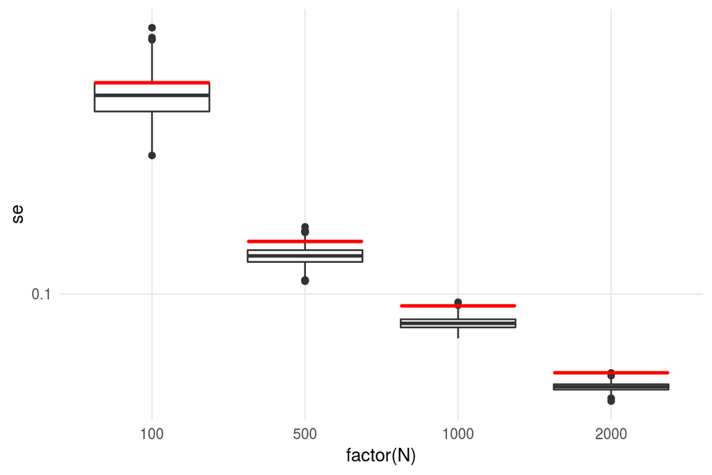

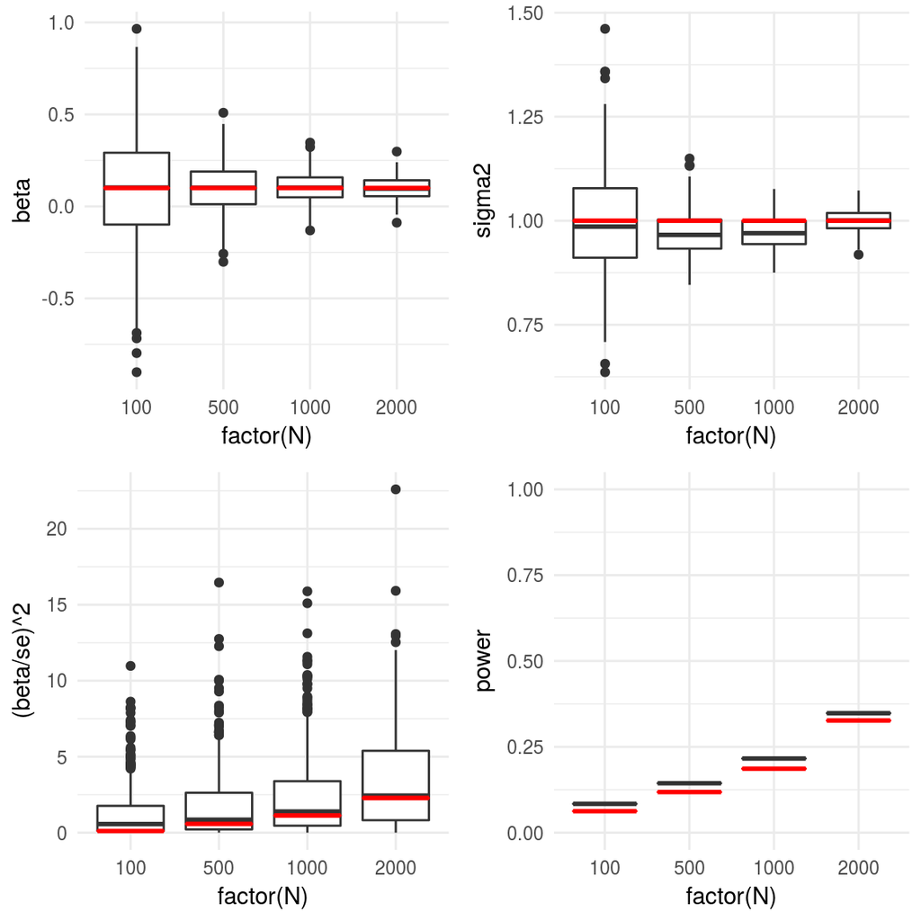

## 5.3 Comparison between unrelated and related (simulations)

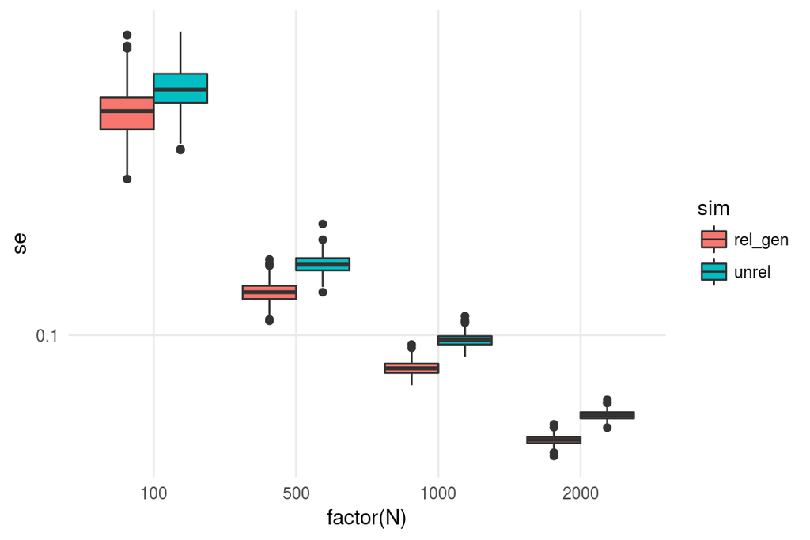

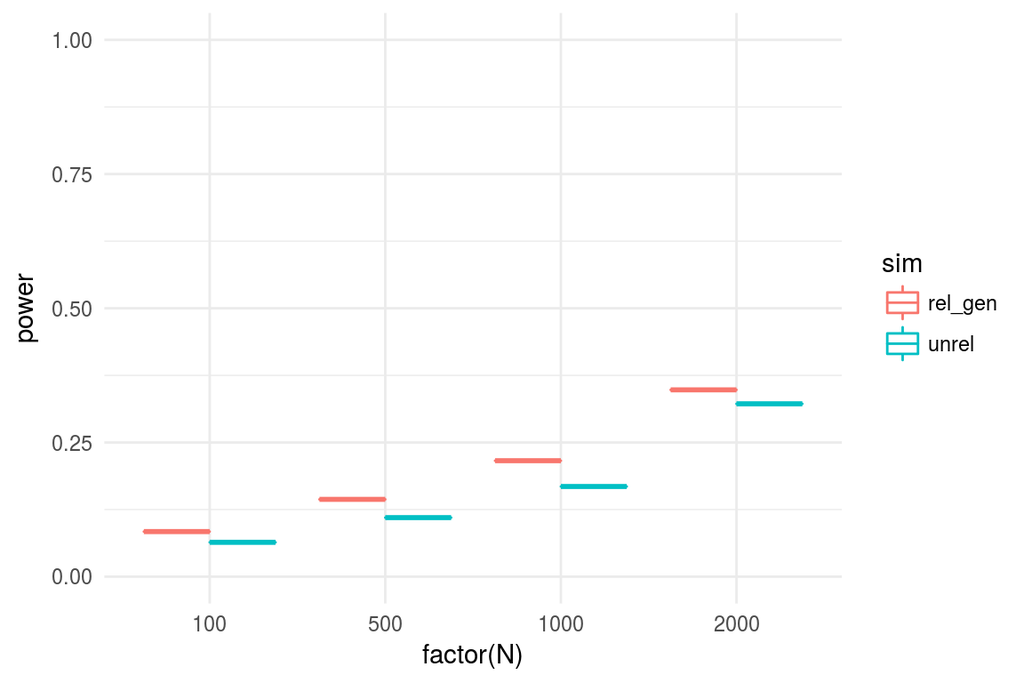

# 6 Conclusions

- The trace factor depends on the structure of related individuals.
  - Does not depend on the sample size if the nuclear families are the same.
- The trace factor in the GxE interaction analysis:
  - the influence of the frequency of exposure $f$
  - the distribution of exposure within and across nuclear families
  - need to derive the analytical formula for sib-pairs

## 6.1 Trace factor matters

| Analysis | Trace factor | Gen. related more powerful (trace factor > 1) |
| --- | --- | --- |
| Main genetic effect | 0.83 | no |
| Interaction GxE effect | 1.02 | yes |